# My Shiny Application

31 October 2017

## Healthy Life Expectancy in Scotland

I have developed an app that takes historical Healthy Life Expectancy (HLE) rates for men and women and displays them on a plot.

It also allows the user to select the range of years displayed, fits a linear model and predicts future or past HLEs.

## What is Healthy Life Expectancy?

According to the [data source](http://statistics.gov.scot/data/healthy-life-expectancy), HLE is:

> HLE is an estimate of how long the average person might be expected to live in a 'healthy' state.

It differs from Life Expectancy, which is more plainly estimate of how many years a person might be expected to live.

It is a key summary of a populations health.

## Displaying the Data

The plot below, is an example of a plot displayed by the app.

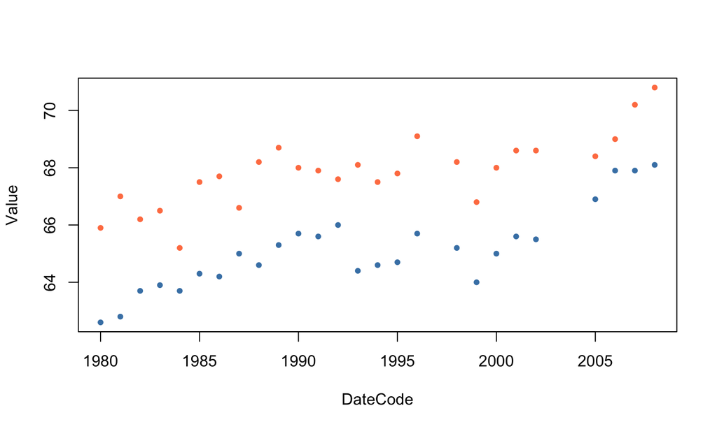

## Predictions

The **Predictions** tab takes the information entered by the user on the side panel, fits a linear model, and predicts the HLE for the year stipulated by the user.

It will also display the relevant statistical information associated with the model.

Thanks for reading.